# part1-data-investigation slides

[figure not shown]

**AI ENTERPRISE WORKFLOW CERTIFICATION**

### Capstone Project - Exporatory Data Analysis

### Data Ingestion

- Let's consider a data ingestion script that readily accepts the data
- We will be using the invoice datasets as a basis for this case study
- Let's start by gathering data from the sources provided

We will be working on the training data given below:

- [capstone-dataset](https://github.com/aavail/ai-workflow-capstone)

**Combine the data into a single data structure**

The two most convenient structures for this task are Pandas dataframes and NumPy arrays.

- A column for country
- A column for invoice_date
- A column for purchases
- A column for unique_invoices
- A column for unique_streams
- A column for total_views
- A column for revenue (target value)

```
...loading timeseries data from files
...creating feature matrix
```

|  | country | invoice_date | purchases | unique_invoices | unique_streams | total_views | revenue |
| --- | --- | --- | --- | --- | --- | --- | --- |
| 0 | eire | 2017-11-28 | 86 | 3 | 83 | 545 | 375.99 |
| 1 | eire | 2017-11-30 | 33 | 1 | 33 | 192 | 194.22 |
| 2 | eire | 2017-12-04 | 64 | 4 | 61 | 403 | 484.65 |
| 3 | eire | 2017-12-05 | 30 | 5 | 30 | 255 | 97.35 |
| 4 | eire | 2017-12-07 | 19 | 1 | 19 | 104 | 133.31 |
| 5 | eire | 2017-12-08 | 2 | 2 | 2 | 7 | 20.90 |
| 6 | eire | 2017-12-10 | 14 | 1 | 14 | 126 | 96.24 |
| 7 | eire | 2017-12-11 | 5 | 1 | 5 | 7 | 17.70 |
| 8 | eire | 2017-12-12 | 100 | 2 | 89 | 733 | 435.58 |
| 9 | eire | 2017-12-13 | 49 | 1 | 49 | 359 | 153.41 |

Top ten rows of the clean dataset

```
...loading timeseries data from files
```

|  | datasize |
| --- | --- |
| eire | 293 |
| france | 285 |
| germany | 359 |
| hong_kong | 9 |
| netherlands | 133 |
| norway | 19 |
| portugal | 72 |
| singapore | 6 |
| spain | 104 |
| total | 495 |
| united_kingdom | 495 |

The are countries with few rows. More data might be useful to accurate analyze them

### Investigative Visualization

Data visualization is the discipline of trying to understand data by placing it in a visual context so that patterns, trends and correlations that might not otherwise be detected can be exposed. The tables we just created above is difficult to navigate it can be useful to use a simple plot to summarize the data. It is possible that both a table and a plot might be needed to communicate the findings and one common practice is to include an appendix in the deliverable.

Another related practice when it comes to EDA is that the communication of your findings, usually via deliverable, is done in a clean and polished way.

The goal here is to see what factors are influencing revenues.

**Analyze Total revenues**

Let's plot the total revenues over time to get a better insight into the data. This will help to understand how total revenues developed over the last years. Remember the objective is to identify the main factors that influence revenues.

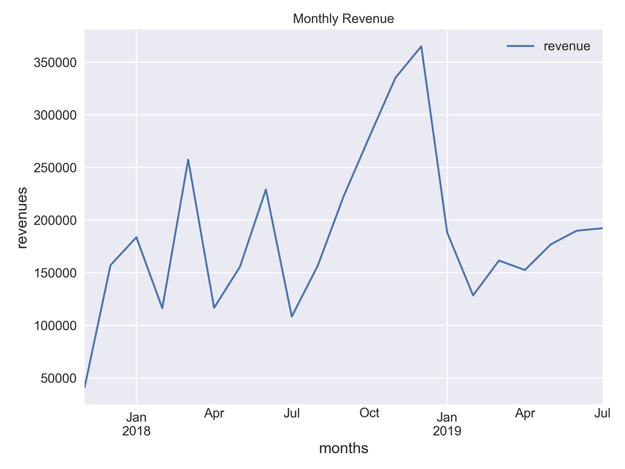

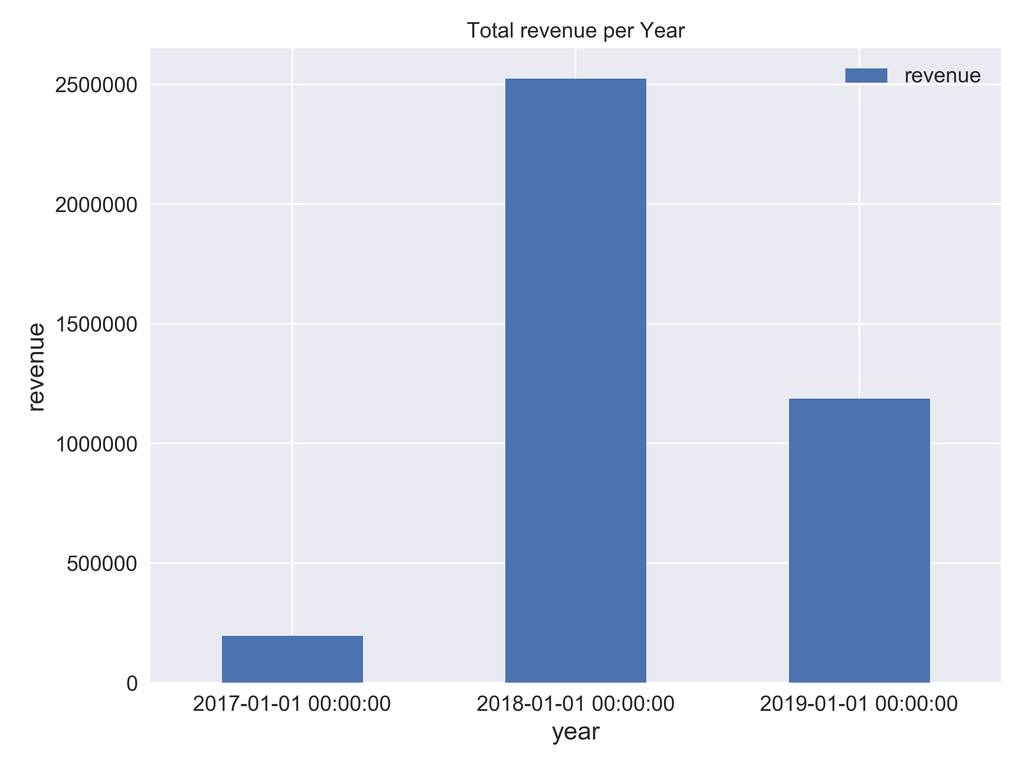

- We cannot say that the total revenues follows a seasonality pattern
- 2018 is the year with the highest revenues (2.5 Million)
- End of 2018 the company realized the highest revenues
- Steep decrease in 2019. Keep in mind that 2019 is not complete

**Analyze revenues per country**

We need to understand how the revenues developed for the top countries.

| country | Total | Percent |
| --- | --- | --- |
| united_kingdom | 3521513.50 | 0.8997 |
| eire | 107069.21 | 0.0274 |
| germany | 49271.82 | 0.0126 |
| france | 40565.14 | 0.0104 |
| norway | 38494.75 | 0.0098 |
| spain | 16040.99 | 0.0041 |
| hong_kong | 14452.57 | 0.0037 |
| portugal | 13528.67 | 0.0035 |
| singapore | 13175.92 | 0.0034 |
| netherlands | 12322.80 | 0.0031 |

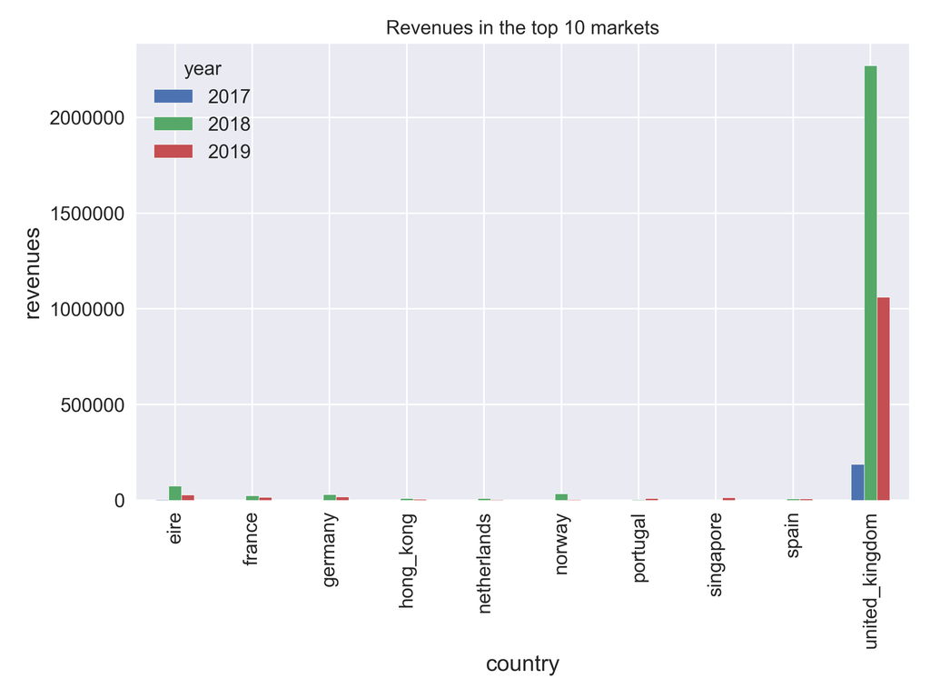

- UK is the main revenue generating market with a share of almost 90%
- EIRE followed with a market share of 3%
- The other markets show significant low revenues.

**Analyze Revenues in UK compared to the Total**

[figure not shown]

### Findings from the analysis of our Features

**As we undertsand that the goal of our data analysis was to find factors that are influencing revenues**

Here are some of the findings of the data analysis:

**Next Steps** Some of the next steps that can be performed are:

- Deep Dive Data analysis on each feature - Shall we transform the numerical features to bring them to a bell-shape distribution?
- Hypothesis testing - We can hypothesize each feature and it's importance.
- We can also calculate multiple types of aggregations for any given feature for better data explorations.